# 朴素贝叶斯

## 数据分析

```python
from collections import Counter
import pandas as pd

data_list = []

with open("spam_train.txt") as f:
    for line in f.readlines():
        tag, words = line.split(" ", 1)
        data_list.append([tag, words])

df = pd.DataFrame(data_list, columns=["label", "text"])
df
```

|  | label | text |
| --- | --- | --- |
| 0 | 1 | public announc the new domain name ar final av... |
| 1 | 1 | have tax problem do you ow the ir monei if you... |
| 2 | 0 | r robert harlei write r scuse me for post in g... |
| 3 | 0 | on wed number oct number brian fahrland wrote ... |
| 4 | 0 | quot ronan waid sure but soft link would do th... |
| 5 | 0 | i notic a low count of razor d spam messag so ... |
| 6 | 1 | nigeria electirc power author feder secretaria... |
| 7 | 0 | on mon number sep number tom wrote if the set ... |
| 8 | 0 | shopper newslett alert live tech help now apri... |
| 9 | 0 | httpaddr summari split up from end in num prod... |
| 10 | 0 | i think that thi and other articl confus socia... |
| 11 | 0 | url httpaddr date number number numbertnumb nu... |
| 12 | 1 | free info free the insid stock market report d... |
| 13 | 0 | i just updat to the latest cv i had been run a... |
| 14 | 0 | on wed jul number number at number number numb... |
| 15 | 0 | on wed jul number number at number number numb... |
| 16 | 0 | jh thei ar legal requir to do that i got a sim... |
| 17 | 0 | url httpaddr date number number numbertnumb nu... |
| 18 | 0 | just for your inform i have an apt repositori ... |
| 19 | 1 | thi is a multi part messag in mime format next... |
| 20 | 0 | url httpaddr date not suppli it will be the on... |
| 21 | 0 | url httpaddr date not suppli new scientist is ... |
| 22 | 1 | thi messag is in mime format sinc your mail re... |
| 23 | 0 | origin messag from r a hettinga free trade and... |
| 24 | 0 | origin messag from ahern peter pahernnumb emai... |
| 25 | 1 | we offer some of the best bulk e mail price on... |
| 26 | 0 | on sat jul number number at number number numb... |
| 27 | 1 | thi is a multi part messag in mime format next... |
| 28 | 0 | on sun jul number number at number number numb... |
| 29 | 0 | url httpaddr date number number numbertnumb nu... |
| ... | ... | ... |
| 4970 | 0 | begin pgp sign messag hash shanumb cauc new vo... |
| 4971 | 0 | on thu number sep number bill stoddard wrote g... |
| 4972 | 0 | you ar receiv thi email becaus you subscrib to... |
| 4973 | 0 | g geeg schuman write g i m sure it s some neur... |
| 4974 | 0 | url httpaddr date wed number sep number number... |
| 4975 | 1 | thi is a multi part messag in mime format next... |
| 4976 | 1 | nbsp royal med nbsp y o u r nbsp nbsp o n l i ... |
| 4977 | 1 | x numberd numberdx x numberd numberdxx numberd... |
| 4978 | 0 | e eirikur hallgrimsson write e gari s new serv... |
| 4979 | 0 | url httpaddr date not suppli some of the word ... |
| 4980 | 1 | nbsp number number number nbsp nbsp nbsp nbsp ... |
| 4981 | 0 | no problem instal openoffic number and number ... |
| 4982 | 0 | i will be out of the offic start number number... |
| 4983 | 1 | smart shopper click here for the best rate pai... |
| 4984 | 0 | thi is an offici mail from sourceforg net you ... |
| 4985 | 0 | on tue aug number number at number number numb... |
| 4986 | 0 | url httpaddr date mon number sep number number... |
| 4987 | 0 | date fri number aug number number number numbe... |
| 4988 | 0 | origin messag from john hall a green onc said ... |
| 4989 | 1 | y o u r last chanc for y o u r dollarnumb numb... |
| 4990 | 0 | i ve a solari box a window number box both wit... |
| 4991 | 0 | satel stevenx wrote when i wa in school thei p... |
| 4992 | 0 | forward by william knowl httpaddr mainichi shi... |
| 4993 | 0 | i got to see powel talk in march number at the... |
| 4994 | 0 | ok i read back that not a typo you mean three ... |
| 4995 | 0 | onc upon a time jess wrote have you thought of... |
| 4996 | 0 | url httpaddr date not suppli i ve been snow un... |
| 4997 | 1 | detail want to refin fill our thi quick form a... |
| 4998 | 0 | url httpaddr date number number numbertnumb nu... |
| 4999 | 0 | soro in open societi sai he ha a theori that t... |

5000 rows × 2 columns

```python
countnormal = Counter(" ".join(df[df['label'] == '1']["text"]).split())
df_normal = pd.DataFrame.from_dict(countnormal.most_common())
df_normal.columns = ["word", "count"]
df_normal
```

|  | word | count |
| --- | --- | --- |
| 0 | number | 36455 |
| 1 | the | 17507 |
| 2 | to | 16057 |
| 3 | and | 11849 |
| 4 | you | 10960 |
| 5 | of | 10554 |
| 6 | nbsp | 10328 |
| 7 | a | 8880 |
| 8 | your | 7098 |
| 9 | for | 6807 |
| 10 | in | 6709 |
| 11 | thi | 5682 |
| 12 | is | 5571 |
| 13 | on | 4743 |
| 14 | i | 3734 |
| 15 | be | 3719 |
| 16 | it | 3712 |
| 17 | that | 3435 |
| 18 | or | 3423 |
| 19 | with | 3320 |
| 20 | dollarnumb | 3318 |
| 21 | ar | 3244 |
| 22 | anumb | 3210 |
| 23 | we | 3142 |
| 24 | will | 2864 |
| 25 | bnumber | 2838 |
| 26 | have | 2785 |
| 27 | our | 2785 |
| 28 | httpaddr | 2703 |
| 29 | mail | 2678 |
| ... | ... | ... |
| 42556 | fnumberfrnumberjkyuynumberpdyrpiketzlnrcovegwljlw | 1 |
| 42557 | yczxuslziacxnumberjlfnumberijyoppyrnumb | 1 |
| 42558 | numbersjypwzucnumberwixk | 1 |
| 42559 | numberhjqanumbergfx | 1 |
| 42560 | hlartdqenumberetnumberqrnwdbmdnumbergpkmzxbvbo... | 1 |
| 42561 | icbqvfnjwkunumberijewijnumberhpcnumbergtnumber... | 1 |
| 42562 | numbersjyzzac | 1 |
| 42563 | wlkzuqxfrnumberjhzhnnumb | 1 |
| 42564 | iibwquxvrtnumberilteipgnumberkpfbbukfnienumber... | 1 |
| 42565 | ianumberkicagicagicagicagicagicagicagicagicagi... | 1 |
| 42566 | frbbjytozdnumbermnumberdfnumberywtbjvvonumberf... | 1 |
| 42567 | enumberbgpyhnumbervvsotpztsyvanumbertnumberunu... | 1 |
| 42568 | xkznumbersnumb | 1 |
| 42569 | iudgnumberxlotnumberxkhjvoazn | 1 |
| 42570 | gdlstbkloxkylmnnumberhwtarnnumbertvdj | 1 |
| 42571 | ugnumberduh | 1 |
| 42572 | numberenumbervwinumberpcgfbsjhqjwataidcjztnejn... | 1 |
| 42573 | wunumberlgvxn | 1 |
| 42574 | panumbero | 1 |
| 42575 | ffuyacgucbqnumberzunumbernpdewqcfurjnumberznum... | 1 |
| 42576 | awvnumberzsbtzswgbwfuesbwzwnumberwbgugdnumberl... | 1 |
| 42577 | ndbnumberlnumberwewcahynumberaeijbepjsnumberls... | 1 |
| 42578 | numberguslnumberwrmhnumb | 1 |
| 42579 | numberkcfaomkcnumberjxnumberysz | 1 |
| 42580 | bnumberjkzxjzigzvcibyzxbvcnqgizquifrobnumbernl... | 1 |
| 42581 | tnumberuifnjwkunumberiinumberxiibgqunfpsjbcmlh... | 1 |
| 42582 | bwnumberkztnumberhymnumberdczmawxlpsnumberwywd... | 1 |
| 42583 | bhqnumberilzpcnumberegqnumberfyzcigcnumberjjps... | 1 |
| 42584 | snumberhoxovkcfnumbercqnumberhyenmnumberktmqnm... | 1 |
| 42585 | pcnumberuujnumberncjxuujnumb | 1 |

42586 rows × 2 columns

随机抽样观察分布。

```python
df_normal[np.random.uniform(0, 1, len(df_normal)) < 0.0001]
```

|  | word | count |
| --- | --- | --- |
| 667 | recommend | 129 |
| 3107 | pam | 12 |
| 15042 | pnumberscnumberuynumbertenumbermcgi | 1 |
| 15602 | sofr | 1 |
| 30744 | wbk | 1 |
| 32273 | ilxfnumberynumberbnumberhvrgwakjwnumbercbnumbe... | 1 |
| 33447 | ewxlpgnumberkpcetlqnumberkicnumberqifnnumberew... | 1 |
| 35115 | qyqxnumberwci | 1 |

```python
df_normal.groupby("count").count()
```

| count | word |
| --- | --- |
| 1 | 30486 |
| 2 | 4138 |
| 3 | 1260 |
| 4 | 1220 |
| 5 | 464 |
| 6 | 516 |
| 7 | 346 |
| 8 | 306 |
| 9 | 218 |
| 10 | 232 |
| 11 | 152 |
| 12 | 163 |
| 13 | 124 |
| 14 | 124 |
| 15 | 114 |
| 16 | 108 |
| 17 | 94 |
| 18 | 96 |
| 19 | 86 |
| 20 | 70 |
| 21 | 55 |
| 22 | 58 |
| 23 | 50 |
| 24 | 56 |
| 25 | 39 |
| 26 | 41 |
| 27 | 38 |
| 28 | 47 |
| 29 | 42 |
| 30 | 36 |
| ... | ... |
| 2674 | 1 |
| 2678 | 1 |
| 2703 | 1 |
| 2785 | 2 |
| 2838 | 1 |
| 2864 | 1 |
| 3142 | 1 |
| 3210 | 1 |
| 3244 | 1 |
| 3318 | 1 |
| 3320 | 1 |
| 3423 | 1 |
| 3435 | 1 |
| 3712 | 1 |
| 3719 | 1 |
| 3734 | 1 |
| 4743 | 1 |
| 5571 | 1 |
| 5682 | 1 |
| 6709 | 1 |
| 6807 | 1 |
| 7098 | 1 |
| 8880 | 1 |
| 10328 | 1 |
| 10554 | 1 |
| 10960 | 1 |
| 11849 | 1 |
| 16057 | 1 |
| 17507 | 1 |
| 36455 | 1 |

528 rows × 1 columns

```python
countspam = Counter(" ".join(df[df['label'] == '0']["text"]).split())
df_spam = pd.DataFrame.from_dict(countspam.most_common())
df_spam.columns = ["word", "count"]
df_spam
```

|  | word | count |
| --- | --- | --- |
| 0 | number | 51315 |
| 1 | the | 39045 |
| 2 | to | 23628 |
| 3 | a | 18806 |
| 4 | and | 17275 |
| 5 | of | 17232 |
| 6 | in | 12278 |
| 7 | i | 12006 |
| 8 | it | 11198 |
| 9 | is | 10966 |
| 10 | httpaddr | 10415 |
| 11 | that | 10216 |
| 12 | on | 9716 |
| 13 | for | 9254 |
| 14 | s | 7769 |
| 15 | you | 7285 |
| 16 | thi | 6361 |
| 17 | with | 5425 |
| 18 | be | 5405 |
| 19 | have | 4541 |
| 20 | t | 4523 |
| 21 | from | 4518 |
| 22 | us | 4434 |
| 23 | as | 4404 |
| 24 | ar | 4317 |
| 25 | not | 4151 |
| 26 | or | 4040 |
| 27 | nbsp | 3994 |
| 28 | at | 3892 |
| 29 | emailaddr | 3832 |
| ... | ... | ... |
| 31178 | gush | 1 |
| 31179 | overclock | 1 |
| 31180 | cleric | 1 |
| 31181 | galor | 1 |
| 31182 | ynumbersbbehwjxgpznumberfgnumberinumberhclcnum... | 1 |
| 31183 | streamer | 1 |
| 31184 | messehal | 1 |
| 31185 | intest | 1 |
| 31186 | dnumberfnumberdnumb | 1 |
| 31187 | filmi | 1 |
| 31188 | firmament | 1 |
| 31189 | hoornweg | 1 |
| 31190 | ijuqaqaqcaaeaaaaaaabaaeaaqeqbgaiaaaanumberaqaa... | 1 |
| 31191 | ecnumbergcsahsawwambslhqgdzdqyonumberdafcoynow... | 1 |
| 31192 | unlicens | 1 |
| 31193 | estaminet | 1 |
| 31194 | mismanag | 1 |
| 31195 | qaikvinumberpmazynumberoegnumberqwcnumberwonum... | 1 |
| 31196 | tnumberlpashknumberuonumberzq | 1 |
| 31197 | piiii | 1 |
| 31198 | kilocalori | 1 |
| 31199 | spelt | 1 |
| 31200 | iiiiiiaiiciiiiiciciiiiiaaaaaaciiiii | 1 |
| 31201 | nimh | 1 |
| 31202 | qieiiayaaaaaamaaaaaaaabgaaaaadafaaabaaaaaqaaaa... | 1 |
| 31203 | mith | 1 |
| 31204 | wgarcacnumberaswdasia | 1 |
| 31205 | undhhnumberia | 1 |
| 31206 | scribe | 1 |
| 31207 | eduardo | 1 |

31208 rows × 2 columns

```python
import matplotlib.pyplot as plt
%matplotlib inline
```

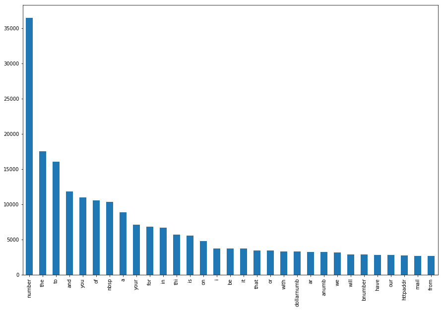

```python
pdf = df_normal.loc[:30]

pdf.plot.bar(legend = False, figsize=(15, 10))
y_pos = np.arange(len(pdf["word"]))
plt.xticks(y_pos, pdf["word"])
plt.show()
```

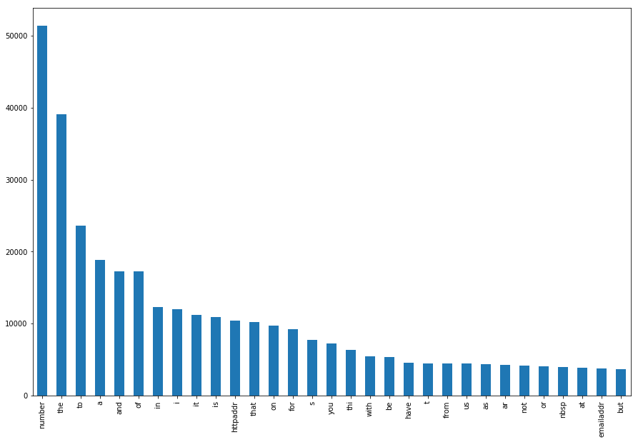

```python
pdf = df_spam.loc[:30]

pdf.plot.bar(legend = False, figsize=(15, 10))
y_pos = np.arange(len(pdf["word"]))
plt.xticks(y_pos, pdf["word"])
plt.show()
```

```python
V = set(list(countspam.keys()) + list(countnormal.keys()))
data = []
for v in V:
    data.append([v, countspam[v], countnormal[v], countspam[v] + countnormal[v]])
pdf = pd.DataFrame.from_records(data, columns=["word", "spam", "normal", "all"])
spam_normal_comparison = pdf.sort_values("all", ascending=False)
spam_normal_comparison
```

|  | word | spam | normal | all |
| --- | --- | --- | --- | --- |
| 4842 | number | 51315 | 36455 | 87770 |
| 59158 | the | 39045 | 17507 | 56552 |
| 23643 | to | 23628 | 16057 | 39685 |
| 37440 | and | 17275 | 11849 | 29124 |
| 46494 | of | 17232 | 10554 | 27786 |
| 37488 | a | 18806 | 8880 | 27686 |
| 58295 | in | 12278 | 6709 | 18987 |
| 65443 | you | 7285 | 10960 | 18245 |
| 11884 | is | 10966 | 5571 | 16537 |
| 37596 | for | 9254 | 6807 | 16061 |
| 5696 | i | 12006 | 3734 | 15740 |
| 16280 | it | 11198 | 3712 | 14910 |
| 42912 | on | 9716 | 4743 | 14459 |
| 1863 | nbsp | 3994 | 10328 | 14322 |
| 40993 | that | 10216 | 3435 | 13651 |
| 31842 | httpaddr | 10415 | 2703 | 13118 |
| 39204 | thi | 6361 | 5682 | 12043 |
| 20909 | s | 7769 | 2577 | 10346 |
| 41081 | your | 3065 | 7098 | 10163 |
| 32755 | be | 5405 | 3719 | 9124 |
| 35985 | with | 5425 | 3320 | 8745 |
| 40399 | ar | 4317 | 3244 | 7561 |
| 39441 | or | 4040 | 3423 | 7463 |
| 35834 | have | 4541 | 2785 | 7326 |
| 45533 | from | 4518 | 2674 | 7192 |
| 861 | us | 4434 | 2381 | 6815 |
| 28787 | as | 4404 | 2304 | 6708 |
| 25701 | not | 4151 | 2462 | 6613 |
| 23345 | t | 4523 | 1495 | 6018 |
| 32069 | by | 3642 | 2266 | 5908 |
| ... | ... | ... | ... | ... |
| 26611 | tnjt | 0 | 1 | 1 |
| 26612 | iiiigaaaaiiagaiiaiiiiiiiiiiiiiiiiiiiiiiiiiiiii... | 1 | 0 | 1 |
| 26613 | dnumberhvbgvzywxlcnumberbvcnrzlnumberbhznumber... | 0 | 1 | 1 |
| 26614 | spinner | 1 | 0 | 1 |
| 26584 | xgdyznysasnumb | 0 | 1 | 1 |
| 26581 | awnumberniglnumberigluigfnumberigxlyxnnumberid... | 0 | 1 | 1 |
| 26547 | flockmeal | 1 | 0 | 1 |
| 26580 | ipxvnnumberalnumberknumberhnumberw | 0 | 1 | 1 |
| 26549 | counterintellig | 1 | 0 | 1 |
| 26551 | dkjvhbmah | 0 | 1 | 1 |
| 26552 | wjsnumbermwhv | 0 | 1 | 1 |
| 26553 | wwgwyqu | 0 | 1 | 1 |
| 26554 | ikk | 0 | 1 | 1 |
| 26555 | ignumberubhkgbwfkzsakmjqwljawigjnumberdcbnumbe... | 0 | 1 | 1 |
| 26557 | cdburn | 1 | 0 | 1 |
| 26558 | bhipaiaggwqgegnumberabhipaaysdwagegnumberagabd... | 0 | 1 | 1 |
| 26559 | nptqnumbertapcbbnumberfznumbersadnumberolhbkao... | 0 | 1 | 1 |
| 26561 | jhpluvqnumberanumberqlegznumbera | 0 | 1 | 1 |
| 26564 | tard | 0 | 1 | 1 |
| 26567 | ijyrknumberfxmknguinumbernpnumberihrnpgwnumber... | 0 | 1 | 1 |
| 26569 | xtksvp | 0 | 1 | 1 |
| 26570 | kodnumberjnumberuapnumbernndonumberwqtnumberqn... | 0 | 1 | 1 |
| 26571 | mzynumberwqlrsyzjgyqsdwrnumberpnumberqcnumberd... | 0 | 1 | 1 |
| 26572 | astoundingli | 1 | 0 | 1 |
| 26573 | jetta | 1 | 0 | 1 |
| 26574 | chirp | 1 | 0 | 1 |
| 26576 | elinumbervhztzprydsyvnumberzykdmmitikzfhnumber... | 1 | 0 | 1 |
| 26578 | jljgcvvovzziwjhprdmgrvnumb | 0 | 1 | 1 |
| 26579 | numbermwl | 0 | 1 | 1 |
| 32906 | ttdfwsnumbermnumberajcyinumberxt | 0 | 1 | 1 |

65812 rows × 4 columns

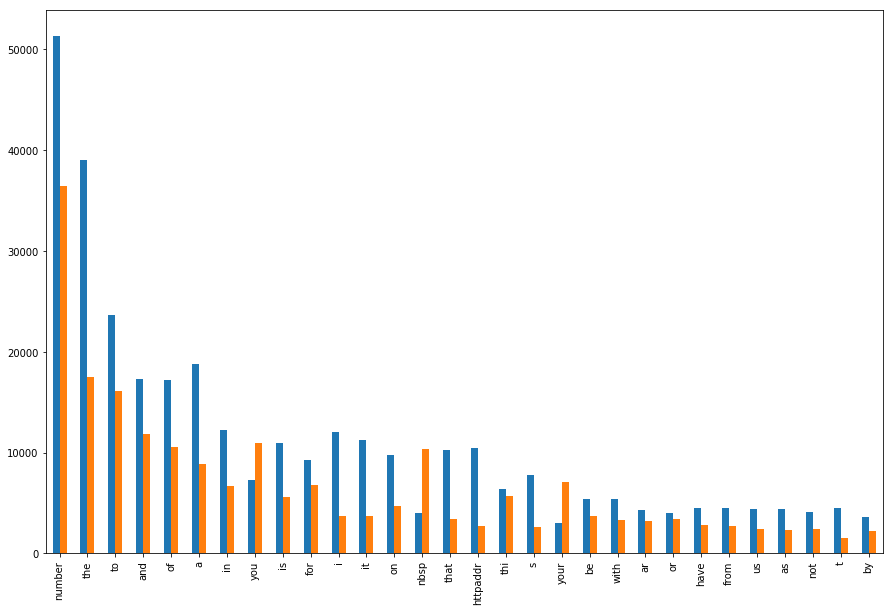

```python
pdf = spam_normal_comparison.iloc[:30]
pdf = pdf.loc[:, ["word", "spam", "normal"]]

pdf.plot.bar(legend = False, figsize=(15, 10))
y_pos = np.arange(len(pdf["word"]))
plt.xticks(y_pos, pdf["word"])
plt.show()
```

可以看到大多数时候垃圾邮件中出现的词汇都是比正常邮件中多的。这与垃圾邮件的绝对数量有关系（所以类别先验是必要的）。

可以过滤掉部分的停用词。

但又注意到 you, your 等单词可能对垃圾邮件区分有帮助，可能不能过滤。

我们将正常邮件中出现的多的词汇先过滤出来。

```python
spam_normal_comparison[spam_normal_comparison.spam < spam_normal_comparison.normal]
```

|  | word | spam | normal | all |
| --- | --- | --- | --- | --- |
| 65443 | you | 7285 | 10960 | 18245 |
| 1863 | nbsp | 3994 | 10328 | 14322 |
| 41081 | your | 3065 | 7098 | 10163 |
| 12799 | we | 2390 | 3142 | 5532 |
| 50802 | will | 2386 | 2864 | 5250 |
| 26199 | dollarnumb | 768 | 3318 | 4086 |
| 17856 | our | 1160 | 2785 | 3945 |
| 18922 | numberd | 1325 | 2612 | 3937 |
| 19905 | email | 1279 | 2635 | 3914 |
| 7243 | no | 1662 | 1798 | 3460 |
| 2474 | anumb | 100 | 3210 | 3310 |
| 22432 | free | 914 | 2217 | 3131 |
| 52650 | here | 1144 | 1745 | 2889 |
| 22702 | bnumber | 33 | 2838 | 2871 |
| 20897 | e | 1134 | 1725 | 2859 |
| 16416 | dnumber | 163 | 2512 | 2675 |
| 42067 | inform | 1195 | 1272 | 2467 |
| 34696 | cnumber | 49 | 2336 | 2385 |
| 64650 | receiv | 540 | 1667 | 2207 |
| 35195 | click | 419 | 1757 | 2176 |
| 65062 | address | 692 | 1446 | 2138 |
| 27855 | pleas | 576 | 1561 | 2137 |
| 2134 | numberc | 55 | 1925 | 1980 |
| 39843 | busi | 506 | 1438 | 1944 |
| 23327 | remov | 367 | 1415 | 1782 |
| 46763 | site | 726 | 1014 | 1740 |
| 42894 | order | 294 | 1443 | 1737 |
| 65293 | send | 622 | 1101 | 1723 |
| 28150 | report | 738 | 947 | 1685 |
| 50791 | name | 543 | 1101 | 1644 |
| ... | ... | ... | ... | ... |
| 26545 | cybpbnrvihntywxsihbpzwnlcwnumberkbnumberigzgnu... | 0 | 1 | 1 |
| 26586 | wcbwbcawzmcvahowqnumbertnumberon | 0 | 1 | 1 |
| 26587 | numberoaenumberienumberkrwmnumberbfipoabnumber... | 0 | 1 | 1 |
| 26599 | numberaaaaaaaaaaaaaaaaaaaaaaaaaaaaaaaaaaaaa | 0 | 1 | 1 |
| 26600 | numberinumberv | 0 | 1 | 1 |
| 26601 | preoccupi | 0 | 1 | 1 |
| 26602 | aorutnumberyejfnumberacyvnumberf | 0 | 1 | 1 |
| 26603 | lyhnumberoibkkgjcgk | 0 | 1 | 1 |
| 26609 | fwfnumberinjllmtjdm | 0 | 1 | 1 |
| 26611 | tnjt | 0 | 1 | 1 |
| 26613 | dnumberhvbgvzywxlcnumberbvcnrzlnumberbhznumber... | 0 | 1 | 1 |
| 26584 | xgdyznysasnumb | 0 | 1 | 1 |
| 26581 | awnumberniglnumberigluigfnumberigxlyxnnumberid... | 0 | 1 | 1 |
| 26580 | ipxvnnumberalnumberknumberhnumberw | 0 | 1 | 1 |
| 26551 | dkjvhbmah | 0 | 1 | 1 |
| 26552 | wjsnumbermwhv | 0 | 1 | 1 |
| 26553 | wwgwyqu | 0 | 1 | 1 |
| 26554 | ikk | 0 | 1 | 1 |
| 26555 | ignumberubhkgbwfkzsakmjqwljawigjnumberdcbnumbe... | 0 | 1 | 1 |
| 26558 | bhipaiaggwqgegnumberabhipaaysdwagegnumberagabd... | 0 | 1 | 1 |
| 26559 | nptqnumbertapcbbnumberfznumbersadnumberolhbkao... | 0 | 1 | 1 |
| 26561 | jhpluvqnumberanumberqlegznumbera | 0 | 1 | 1 |
| 26564 | tard | 0 | 1 | 1 |
| 26567 | ijyrknumberfxmknguinumbernpnumberihrnpgwnumber... | 0 | 1 | 1 |
| 26569 | xtksvp | 0 | 1 | 1 |
| 26570 | kodnumberjnumberuapnumbernndonumberwqtnumberqn... | 0 | 1 | 1 |
| 26571 | mzynumberwqlrsyzjgyqsdwrnumberpnumberqcnumberd... | 0 | 1 | 1 |
| 26578 | jljgcvvovzziwjhprdmgrvnumb | 0 | 1 | 1 |
| 26579 | numbermwl | 0 | 1 | 1 |
| 32906 | ttdfwsnumbermnumberajcyinumberxt | 0 | 1 | 1 |

36983 rows × 4 columns

这是一份从网上得到的停用词列表：

```python
BUILTIN_STOPWORDS = [
    "a", "about", "above", "across", "after", "afterwards", "again", "against",
    "all", "almost", "alone", "along", "already", "also", "although", "always",
    "am", "among", "amongst", "amoungst", "amount", "an", "and", "another",
    "any", "anyhow", "anyone", "anything", "anyway", "anywhere", "are",
    "around", "as", "at", "back", "be", "became", "because", "become",
    "becomes", "becoming", "been", "before", "beforehand", "behind", "being",
    "below", "beside", "besides", "between", "beyond", "bill", "both",
    "bottom", "but", "by", "call", "can", "cannot", "cant", "co", "con",
    "could", "couldnt", "cry", "de", "describe", "detail", "do", "done",
    "down", "due", "during", "each", "eg", "eight", "either", "eleven", "else",
    "elsewhere", "empty", "enough", "etc", "even", "ever", "every", "everyone",
    "everything", "everywhere", "except", "few", "fifteen", "fifty", "fill",
    "find", "fire", "first", "five", "for", "former", "formerly", "forty",
    "found", "four", "from", "front", "full", "further", "get", "give", "go",
    "had", "has", "hasnt", "have", "he", "hence", "her", "here", "hereafter",
    "hereby", "herein", "hereupon", "hers", "herself", "him", "himself", "his",
    "how", "however", "hundred", "i", "ie", "if", "in", "inc", "indeed",
    "interest", "into", "is", "it", "its", "itself", "keep", "last", "latter",
    "latterly", "least", "less", "ltd", "made", "many", "may", "me",
    "meanwhile", "might", "mill", "mine", "more", "moreover", "most", "mostly",
    "move", "much", "must", "my", "myself", "name", "namely", "neither",
    "never", "nevertheless", "next", "nine", "no", "nobody", "none", "noone",
    "nor", "not", "nothing", "now", "nowhere", "of", "off", "often", "on",
    "once", "one", "only", "onto", "or", "other", "others", "otherwise", "our",
    "ours", "ourselves", "out", "over", "own", "part", "per", "perhaps",
    "please", "put", "rather", "re", "same", "see", "seem", "seemed",
    "seeming", "seems", "serious", "several", "she", "should", "show", "side",
    "since", "sincere", "six", "sixty", "so", "some", "somehow", "someone",
    "something", "sometime", "sometimes", "somewhere", "still", "such",
    "system", "take", "ten", "than", "that", "the", "their", "them",
    "themselves", "then", "thence", "there", "thereafter", "thereby",
    "therefore", "therein", "thereupon", "these", "they", "thick", "thin",
    "third", "this", "those", "though", "three", "through", "throughout",
    "thru", "thus", "to", "together", "too", "top", "toward", "towards",
    "twelve", "twenty", "two", "un", "under", "until", "up", "upon", "us",
    "very", "via", "was", "we", "well", "were", "what", "whatever", "when",
    "whence", "whenever", "where", "whereafter", "whereas", "whereby",
    "wherein", "whereupon", "wherever", "whether", "which", "while", "whither",
    "who", "whoever", "whole", "whom", "whose", "why", "will", "with",
    "within", "without", "would", "yet", "you", "your", "yours", "yourself",
    "yourselves"
]
```

```python
good_words = set(spam_normal_comparison[spam_normal_comparison.spam < spam_normal_comparison.normal].word)
STOPWORDS2 = list(word for word in BUILTIN_STOPWORDS if word not in good_words)
STOPWORDS2
```

```
['a',
 'about',
 'above',
 'across',
 'after',
 'afterwards',
 'again',
 'against',
 'all',
 'almost',
 'alone',
 'along',
 'already',
 'also',
 'although',
 'always',
 'am',
 'among',
 'amongst',
 'amoungst',
 'an',
 'and',
 'another',
 'any',
 'anyhow',
 'anyone',
 'anything',
 'anyway',
 'anywhere',
 'are',
 'around',
 'as',
 'at',
 'back',
 'be',
 'became',
 'because',
 'become',
 'becomes',
 'becoming',
```

[output cut: 232 more lines]

```
 'which',
 'while',
 'whither',
 'who',
 'whoever',
 'whole',
 'whom',
 'whose',
 'why',
 'with',
 'without',
 'would',
 'yet',
 'yours',
 'yourselves']
```

## 特征提取

可以过滤掉停用词。

这里，同时也（顺带）过滤掉了「只出现过一次的单词」和「长度超过 20 的单词」。可能可以提高一些速度，但由于这些单词本身对结果影响就较小，可能并不会影响最终的正确率。

```python
word_list = []

with open("spam_train.txt") as f:
    for line in f.readlines():
        tag, words = line.split(" ", 1)
        word_list.extend(words.split())

with open("spam_test.txt") as f:
    for line in f.readlines():
        data_list.extend(line.split())

df_words = pd.DataFrame.from_dict(Counter(word_list).most_common())
df_words.columns = ["Word", "Count"]
added_stopwords = list(df_words[~((df_words.Count > 1) & (df_words.Word.str.len() < 20))].Word)
```

```python
stopwords = STOPWORDS2

stopwords.extend(added_stopwords)

stopwords = frozenset(stopwords)
len(stopwords)
```

```
44333
```

```python
from sklearn import feature_extraction, model_selection, naive_bayes, metrics

f = feature_extraction.text.CountVectorizer(stop_words = stopwords)
X = f.fit_transform(df["text"])
np.shape(X)
```

```
(5000, 21555)
```

## 朴素贝叶斯的实现

这里的朴素贝叶斯，使用了 [sklearn](http://scikit-learn.org/stable/modules/naive_bayes.html#multinomial-naive-bayes) 上的公式进行实现。在不考虑很多数据上的普适性、错误、异常的情况下，实现起来还是比较简单的。

由于矩阵规模较大，且比较稀疏，所以可能额外增加了一定的成本。

```python
from sklearn.metrics import accuracy_score
import numpy as np

class NaiveBayes:

    def __init__(self, alpha=0.1):
        self.alpha = alpha

    def fit(self, X, y):
        self.classes = np.unique(y)
        self.n_classes = len(self.classes)
        self.n_features = X.shape[1]
        self.n_samples = X.shape[0]

        separated_tests = [np.array(list(map(lambda x: x[0], filter(lambda y: y[1] == c, zip(X, y))))) for c in self.classes]
        self.class_log_prior = np.array([len(cls_) / self.n_samples for cls_ in separated_tests])

        self.feature_log_prior = np.array([data.sum(axis=0).toarray().reshape((self.n_features, )) for data in separated_tests])

        for i in range(self.n_classes):
            tot = self.feature_log_prior[i].sum()
            self.feature_log_prior[i] = np.log((self.feature_log_prior[i] + self.alpha) / (tot + self.n_classes * self.alpha))

    def predict_log_proba(self, X):
        return np.array([(self.feature_log_prior * x.toarray()).sum(axis=1) + self.class_log_prior for x in X])

    def predict(self, X):
        return np.array(list(map(lambda x: self.classes[x], np.argmax(self.predict_log_proba(X), axis=1))))

    def score(self, X, y):
        return accuracy_score(self.predict(X), y)
```

```python
for test in range(0, 11):
    alpha = 0.001 + test * 0.1
    trainX, testX, trainY, testY = model_selection.train_test_split(X, df['label'], test_size=0.33)
    bayes = NaiveBayes(alpha=alpha)
    bayes.fit(trainX, trainY)
    print("Test #%d:" % test)
    print("My:", bayes.score(trainX, trainY), bayes.score(testX, testY))

    bayes = naive_bayes.MultinomialNB(alpha=alpha)
    bayes.fit(trainX, trainY)
    print("Official:", bayes.score(trainX, trainY), bayes.score(testX, testY))
```

```
Test #0:
My: 0.991641791045 0.974545454545
Official: 0.992537313433 0.973939393939
Test #1:
My: 0.988656716418 0.979393939394
Official: 0.989552238806 0.978181818182
Test #2:
My: 0.988656716418 0.982424242424
Official: 0.98776119403 0.984242424242
Test #3:
My: 0.988358208955 0.973333333333
Official: 0.98776119403 0.975757575758
Test #4:
My: 0.986865671642 0.979393939394
Official: 0.986567164179 0.977575757576
Test #5:
My: 0.988358208955 0.976363636364
Official: 0.988358208955 0.975757575758
Test #6:
My: 0.987462686567 0.97696969697
Official: 0.988358208955 0.978181818182
Test #7:
My: 0.989552238806 0.97696969697
Official: 0.986865671642 0.98
Test #8:
My: 0.986268656716 0.97696969697
Official: 0.985970149254 0.97696969697
Test #9:
My: 0.988955223881 0.973333333333
Official: 0.989253731343 0.974545454545
Test #10:
My: 0.985671641791 0.975757575758
Official: 0.986567164179 0.978181818182
```

可能由于已经去除了出现次数很少的单词的关系，alpha 值的选取对结果影响并不大。

实验结果在 97% 到 98% 之间浮动。事实上我在一开始做这个实验的时候，直接使用了网上的停用词，准确率也能达到这个水平。如此增加了大量的分析，颇有一种「结果不重要，过程炫酷就行」的感觉。

```python
data_list = []

with open("spam_test.txt") as f:
    for line in f.readlines():
        data_list.append(line)


f = feature_extraction.text.CountVectorizer(stop_words = stopwords)
f.fit(data_list + list(df["text"]))
testX = f.transform(data_list)
trainX = f.transform(df["text"])
trainY = df["label"]
print(np.shape(testX))
print(np.shape(trainX))

bayes = NaiveBayes(alpha=0.001)
bayes.fit(trainX, trainY)
t = bayes.predict(testX)
with open("result.txt", "w") as f:
    f.write('\n'.join(map(str, t)))
```

```
(1000, 35753)
(5000, 35753)
```